# Yellow-legged Frog Abundance (Task 1)

Lucas Boyd

1/20/2022

### Overview

The following report wrangles and visualizes amphibian abundance data recorded by the Sierra Lakes Inventory Project. First, the code wrangles data to show total counts of yellow-legged frogs across three life cycle stages for each year that data was collected. Then, the code wrangles and visualizes counts of yellow-legged frogs by the lake in the lakes that they were most abundant.

### Set up and reading in the data

```r
knitr::opts_chunk$set(echo = TRUE, message = FALSE, warning = FALSE)
# attach packages
library(tidyverse)
library(broom)
library(janitor)
library(here)
library(readxl)
library(lubridate)
library(patchwork)
```

```r
# reading in the amphibians data
amphib <- read_xlsx(here("data", "sierra_amphibians.xlsx")) %>%
  mutate(year = year(survey_date)) # pulling out a new column for year with lubridate
```

### Wrangling and visualizing frog counts by year

```r
# filtering only for yellow-legged frogs at adult, sub-adult and tadpole life stages
frogs <- amphib %>%
  filter(amphibian_species == "RAMU") %>%
  filter(amphibian_life_stage %in% c("Adult", "SubAdult", "Tadpole"))

frogs_count <- frogs %>% # getting counts of frogs by year and life stage
  count(year, amphibian_life_stage)
```

```r
# visualizing the data with ggplot
g1 <- ggplot(data = frogs_count, aes(x = as.factor(year), y = n, fill = amphibian_life_stage)) +
  geom_col(width = 0.7) + # adding geometry
  scale_fill_manual(values = c("goldenrod4", "goldenrod2", "lightgoldenrod2" )) + # customizing colors
  theme_minimal(12) + # adding theme
  labs(x = "Survey Collection Year", y = "Survey Counts") + # changing labels
  theme(legend.title = element_blank(), legend.position = c(0.2,0.85), axis.text.x = element_text(vjust = 7)) # adjusting text and aesthetics
```

### Wrangling and visualizing total frog counts by lake

```r
# filtering for only adult and sub-adult yellow-legged frogs and finding total counts for each lake
frogs_lakes <- frogs %>%
  filter(amphibian_life_stage %in% c("SubAdult", "Adult")) %>%
  count(lake_id) %>%
  mutate(lake_id = as_factor(lake_id)) %>% # changing lake_id to a factor
    slice_max(order_by = n, n = 5) %>% # reataining only top 5 most prolific lakes, ordering data
  mutate(lake = "Lake") %>% # changing the text of the lake id column to a label
  unite("lake_id", lake, lake_id, sep = " ")
```

```r
# visualizing the data with ggplot
g2 <- ggplot(data = frogs_lakes, aes(x = fct_reorder(lake_id, n), y = n, fill = lake_id)) +
         geom_col(width = 0.75) + # adding a geometry
  labs(x = element_blank(), y = "Total Survey Count") + # changing labels
  scale_fill_manual(values = c("darkolivegreen3", "darkolivegreen3", "darkolivegreen", "darkolivegreen3", "darkolivegreen4")) + # customizing colors
    theme_minimal(12) + # adding theme
  theme(legend.position = "none") + # removing legend
  coord_flip() + # flipping axes
  theme(axis.text.x = element_text(vjust = 7), axis.text.y = element_text(margin = margin(t = 0, r = -10, b = 0, l = 0))) # adjusting text
```

### Finalized plots

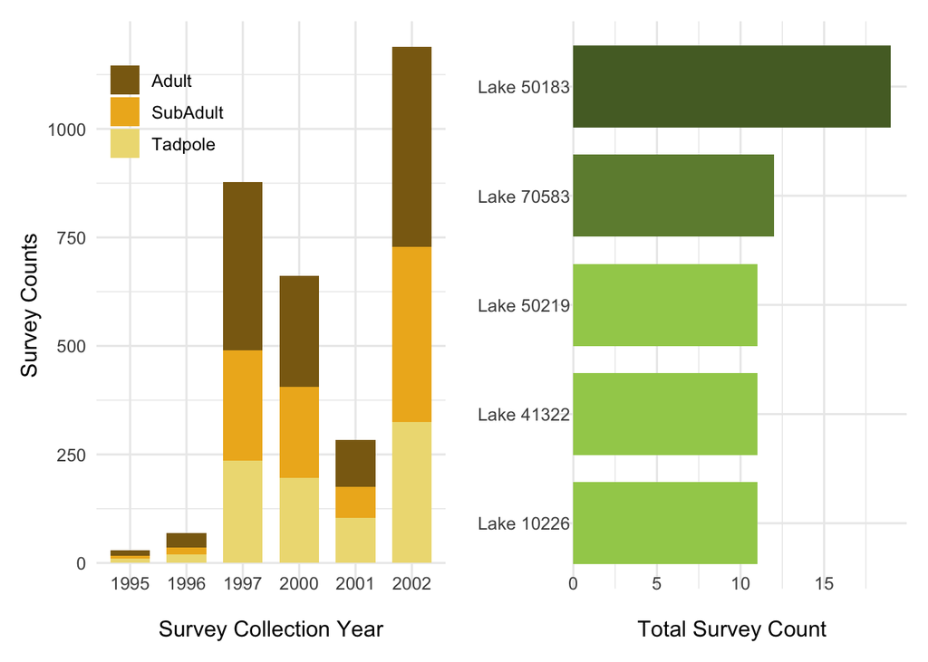

```r
# placing the plots next to eachother
( g1 | g2 )
```

**Fig. 1** shows the survey collection counts of yellow-legged frogs (Rana Mucosa). The **Left** panel displays total counts of yellow-legged frogs by each year that data was collected. Observations for adult, sub-adult and tadpole are included in the figure. The **Right** panel shows total counts of yellow-legged frogs observed across all years of collection, organized by the lake in which they were observed. The top 5 lakes where the most frogs were observed are retained for the figure.

### Data citation

Knapp, R.A., C. Pavelka, E.E. Hegeman, and T.C. Smith. 2020. The Sierra Lakes Inventory Project: Non-Native fish and community composition of lakes and ponds in the Sierra Nevada, California ver 2. Environmental Data Initiative. https://doi.org/10.6073/pasta/d835832d7fd00d9e4466e44eea87fab3